# Assignment 2, Task 2

Catherine Takata

2/7/2021

## **Overview**

By manipulating the Florida palmetto data, we can utilize binary logistic regression to isolate plant height (height), canopy length (length), canopy width (width), and number of green leaves (green_lvs) to classify whether a palmetto is species Serenoa repens or Sabal etonia.

```r
# Read in data set locally

palmetto <- read_csv(here("data", "palmetto.csv"),
                     col_types = cols(.default = 'c')) %>%
  mutate(height = as.numeric(height))
```

```r
# Data wrangle to isolate specified variables
# Use select() to pull columns to create a new dataset
# Mutate() or "add" new columns of data
# Use as.numeric to create "numeric" data classes that can be used to calculating blr

palmetto_species <- palmetto %>%
  select(species, height, length, width, green_lvs) %>%
  mutate(species_name = case_when(
    species %in% "1" ~ "Serenoa repens",
    species %in% "2" ~ "Sabal etonia"
  )) %>%
  mutate(species_name = factor(species_name)) %>%
  mutate(length = as.numeric(length)) %>%
  mutate(width = as.numeric(width)) %>%
  mutate(green_lvs = as.numeric(green_lvs))
```

## **Data Visualization Exploration**

Data visualizations exploring differences in height, canopy length, canopy width, and green leaves for Serenoa repens or Sabal etonia.

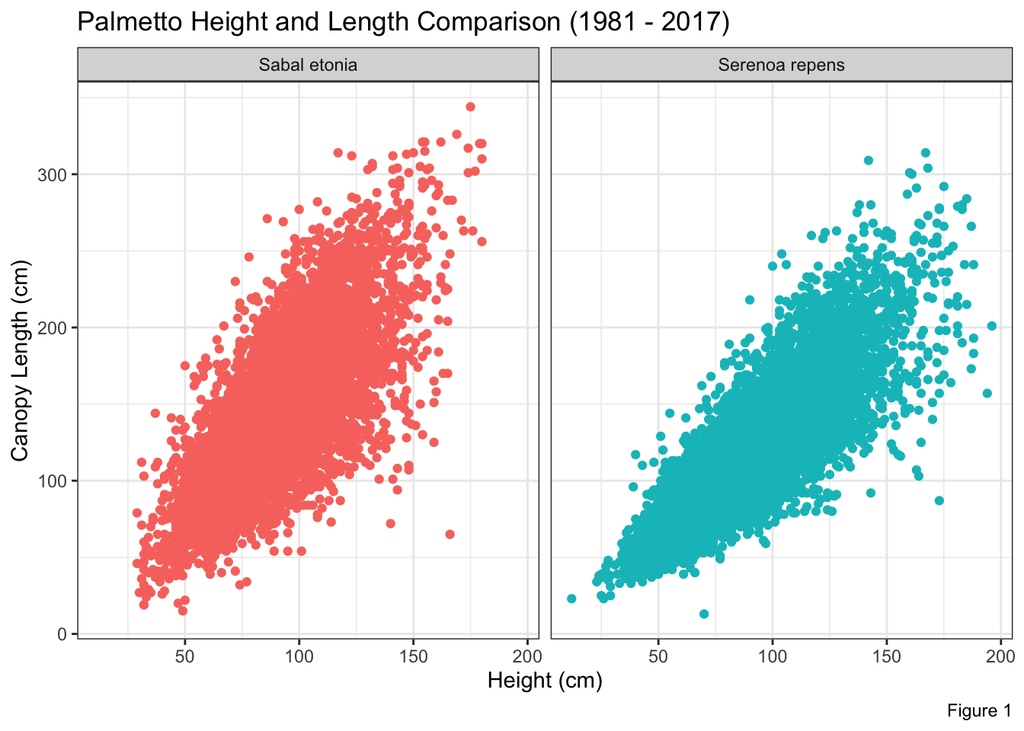

```r
ggplot(data = palmetto_species, aes(x = height, y = length)) +
  geom_point(aes(color = species_name), show.legend = F) +
  facet_wrap(~species_name) +
  theme_bw() +
  labs(
    title = "Palmetto Height and Length Comparison (1981 - 2017)",
    caption = "Figure 1",
    x = "Height (cm)",
    y = "Canopy Length (cm)"
  )
```

The height and canopy length of the two species of Palmetto have similar positive trends and data spread.

[figure not shown]

```r
ggplot(data = palmetto_species, aes(x = width, y = length)) +
  geom_point(aes(color = species_name), show.legend = F) +
  facet_wrap(~species_name) +
  theme_bw() +
  labs(
    title = "Palmetto Height and Width Comparison (1981 - 2017)",
    caption = "Figure 2",
    x = "Canopy Width (cm)",
    y = "Canopy Length (cm)"
  )
```

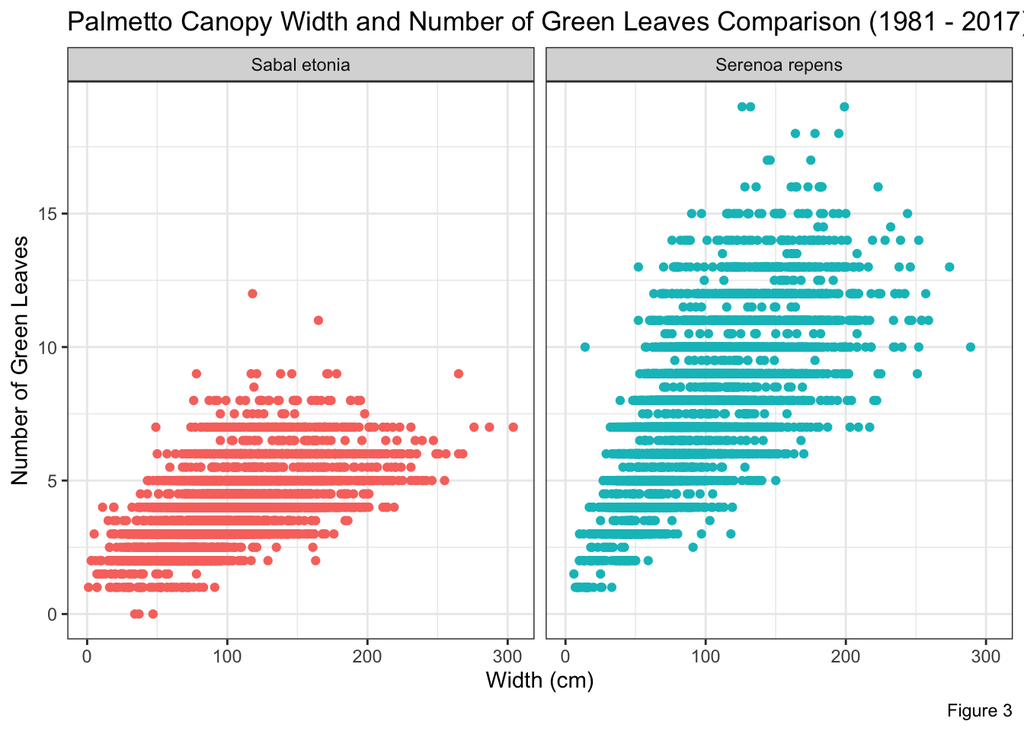

```r
ggplot(data = palmetto_species, aes(x = width, y = green_lvs)) +
  geom_point(aes(color = species_name), show.legend = F) +
  facet_wrap(~species_name) +
  theme_bw() +
  labs(
    title = "Palmetto Canopy Width and Number of Green Leaves Comparison (1981 - 2017)",
    caption = "Figure 3",
    x = "Width (cm)",
    y = "Number of Green Leaves"
  )
```

We use binary logistic regression of plant height, canopy length, canopy width, and green leaves as predictor variables to understand how they relate to probability of a plant being Serenoa repens or Sabal etonia

```r
palmetto_blr <- glm(species_name ~ height + length + width + green_lvs,
                    data = palmetto_species,
                    family = "binomial")
```

**Table 1**: Results of the binary logistic regression model based on plant height, canopy length, canopy width, and green leaves predicator variables.

```r
# Use broom::tidy() to clean and simplify the data in order to present in a table

blr_tidy <- broom::tidy(palmetto_blr) %>%
  mutate(p.value = case_when(
    p.value < 0.0001 ~ "<0.0001"
  ))

kbl(blr_tidy,
    col.names = c("", "Estimate", "Standard Error", "Statistic", "p - value") ) %>%
  kable_styling(bootstrap_options = "striped", full_width = FALSE)
```

|  | Estimate | Standard Error | Statistic | p - value |
| --- | --- | --- | --- | --- |
| (Intercept) | -3.2266851 | 0.1420708 | -22.71180 | <0.0001 |
| height | 0.0292173 | 0.0023061 | 12.66984 | <0.0001 |
| length | -0.0458233 | 0.0018661 | -24.55600 | <0.0001 |
| width | -0.0394434 | 0.0021000 | -18.78227 | <0.0001 |
| green_lvs | 1.9084747 | 0.0388634 | 49.10728 | <0.0001 |

**Table 2**: Classification of Palmetto species based on results of binary logisitc regression of predictor variable. For species Sabal etonia and Serenoa repens, there is a correctly classified percentage of 92.62% and 90.77%, respectively, after qualifying a >= 50% cutoff.

```r
# Use broom::augment() to create a tidy summary of the data in a neat table.
# Use case_when() as an if/else statement to isolate inequalitites of >= 0.50 in order to classify species predicted.

blr_fitted <- palmetto_blr %>%
  broom::augment(type.predict = "response") %>%
  mutate(model_prediction = case_when(
    .fitted >= .50 ~ "Serenoa repens",
    .fitted <.50 ~ "Sabal etonia"
  )) %>%
  mutate(correct_classify = case_when(
    species_name == model_prediction ~ "correct",
    TRUE ~ "incorrect"
  )) %>%
  select(species_name, correct_classify) %>%
  group_by(species_name, correct_classify) %>%
  summarise(number_correct = n()) %>%
  pivot_wider(names_from = correct_classify,
              values_from = number_correct) %>%
  mutate(percent_correct = correct/(correct+incorrect)*100)

# Use kbl() to create a neat table, rename titles, and order data

kbl(blr_fitted,
    col.names = c("", "Number Correctly Predicted", "Number Incorrectly Predicted", "Percent Correct")) %>%
  kable_styling(bootstrap_options = "striped", full_width = FALSE)
```

|  | Number Correctly Predicted | Number Incorrectly Predicted | Percent Correct |
| --- | --- | --- | --- |
| Sabal etonia | 5701 | 454 | 92.62388 |
| Serenoa repens | 5548 | 564 | 90.77225 |